# Predicting Gasoline Prices

Amber Han | amberhan@ucsb.edu

2026-03-07

## Abstract

In a culture, city, state, and nation that relies on car transportation, gasoline consumption is essential for the every day person. The prices are present and affect people’s lives everyday in the form of cost of commuting to work, the price for groceries being transported to the local grocery store, it’s even essential for those that don’t use car transportation. For some individuals, the slightest increase in price can impact their lives disproportionately where a large chunk of their income can go towards fuel costs. The logistics of fuel costs can be relevant for businesses and supply chain costs. Policymakers are relied upon to do what they can to lower the prices and must foster good relations with other policymakers to ensure access to fuel at all. The price of fuel keeps politics attached to people for the rest of their lives and being able to predict prices may assist others in preparation for changes in their lives.

## 1. Introduction

The reason I chose this topic is because the price of gasoline is always contentious and political varying from region to region. Gasoline prices in California alone vary so much, I can only imagine how different they are in non-cosmopolitan areas of the United States. I’m curious to see how the prices of gas change as the political climate has evolved over the years. Maybe I can predict the gas prices so I have a heads up on the prices I will have to pay after next presidential election.

My project takes a data set of weekly U.S. retail gasoline prices from January 1995 to January 2021 and models it using Seasonal Autoregressive Integrated Moving Average (SARIMA) and Generalized Autoregressive Conditionally Heteroskedastic (GARCH) modeling. The data set is sourced from the U.S. Energy Information Administration and consists of 1,361 weekly observations measured in dollars per gallon. In order to do SARIMA, I confirmed the non-stationarity of my data set using ACF and PACF analysis, as well applying first differencing to make the series stationary in the end. I compared five different SARIMA models in order to decide which model was best fit, comparing specifically the AIC, or the Akaike Information Criterion. My SARIMA(1,1,1)(0,1,1)[52] model resulted in the lowest AIC and thus I created a 12 week forecast based on this model. The forecast displayed a moderate upward trend in gasoline prices, rising between $2.50 to $2.75 per gallon.

Following this model, I chose to do a GARCH(1,1) model on the SARIMA residuals to capture volatility. After confirming the presence of ARCH effects, I went ahead to perform GARCH(1,1) following a normal distribution. I observed some extreme shocks that did not seem consistent with a normal distribution. So additionally I fit a student-t distribution, a continuous distribution that generalizes the standard normal distribution, and a skewed student-t distribution to generalize the student-t distribution by allowing for non-zero skewness. Both of these were chosen to better accommodate the shocks I observed and are used to compare forecasts to the normal distribution assumption.

## 2. Data

The data set starts from January 1995 and ends at January 2021. The frequency of the data set is weekly. The units are in USD, price per gallon. The values are all non-negative values. There are 1,361 observations.

I discovered and downloaded the data from [Kaggle](https://www.kaggle.com/datasets/mruanova/us-gasoline-and-diesel-retail-prices-19952021?resource=download)

The data was originally collected from the [U.S. Energy Information Administration](https://www.eia.gov/dnav/pet/pet_pri_gnd_dcus_nus_w.htm) in January of 2021.

The purpose of studying this data set is to see how gasoline prices correlate to political and national events as well as the seasonal patterns. The long time frame offered by the data set will provide me with enough content that should reliably reflect the trends and patterns that cause fluctuations in gasoline prices.

The data set consists of the variables:

- A1: Weekly U.S. *All Grades All Formulations* Retail Gasoline Prices (Dollars per Gallon)
- A2: Weekly U.S. *All Grades Conventional* Retail Gasoline Prices (Dollars per Gallon)
- A3: Weekly U.S. *All Grades Reformulated* Retail Gasoline Prices (Dollars per Gallon
- R1: Weekly U.S. *Regular All Formulations* Retail Gasoline Prices (Dollars per Gallon)
- R2: Weekly U.S. *Regular Conventional* Retail Gasoline Prices (Dollars per Gallon)
- R3: Weekly U.S. *Regular Reformulated* Retail Gasoline Prices (Dollars per Gallon)
- M1: Weekly U.S. *Midgrade All Formulations* Retail Gasoline Prices (Dollars per Gallon)
- M2: Weekly U.S. *Midgrade Conventional* Retail Gasoline Prices (Dollars per Gallon)
- M3: Weekly U.S. *Midgrade Reformulated* Retail Gasoline Prices (Dollars per Gallon)
- P1: Weekly U.S. *Premium All Formulations* Retail Gasoline Prices (Dollars per Gallon)
- P2: Weekly U.S. *Premium Conventional Retail* Gasoline Prices (Dollars per Gallon)
- P3: Weekly U.S. *Premium Reformulated Retail* Gasoline Prices (Dollars per Gallon)
- D1: Weekly U.S. *No 2 Diesel Retail* Prices (Dollars per Gallon)

### Reading in my data

[Gasoline Data Link](https://www.kaggle.com/datasets/mruanova/us-gasoline-and-diesel-retail-prices-19952021?resource=download)

```r
gasoline <- read.csv("gasoline.csv")
glimpse(gasoline)
```

```
## Rows: 1,361
## Columns: 14
## $ Date <chr> "01/02/1995", "01/09/1995", "01/16/1995", "01/23/1995", "01/30/19…
## $ A1   <dbl> 1.127, 1.134, 1.126, 1.132, 1.131, 1.124, 1.121, 1.115, 1.121, 1.…
## $ A2   <dbl> 1.104, 1.111, 1.102, 1.110, 1.109, 1.103, 1.099, 1.093, 1.101, 1.…
## $ A3   <dbl> 1.231, 1.232, 1.231, 1.226, 1.221, 1.218, 1.218, 1.213, 1.211, 1.…
## $ R1   <dbl> 1.079, 1.086, 1.078, 1.083, 1.083, 1.076, 1.074, 1.067, 1.073, 1.…
## $ R2   <dbl> 1.063, 1.070, 1.062, 1.068, 1.068, 1.062, 1.058, 1.052, 1.060, 1.…
## $ R3   <dbl> 1.167, 1.169, 1.169, 1.165, 1.162, 1.159, 1.158, 1.153, 1.152, 1.…
## $ M1   <dbl> 1.170, 1.177, 1.168, 1.177, 1.176, 1.169, 1.166, 1.160, 1.164, 1.…
## $ M2   <dbl> 1.159, 1.164, 1.155, 1.165, 1.163, 1.157, 1.153, 1.148, 1.153, 1.…
## $ M3   <dbl> 1.298, 1.300, 1.299, 1.296, 1.291, 1.288, 1.285, 1.280, 1.276, 1.…
## $ P1   <dbl> 1.272, 1.279, 1.271, 1.277, 1.275, 1.270, 1.265, 1.259, 1.265, 1.…
## $ P2   <dbl> 1.250, 1.256, 1.249, 1.256, 1.255, 1.250, 1.243, 1.239, 1.246, 1.…
## $ P3   <dbl> 1.386, 1.387, 1.385, 1.378, 1.370, 1.368, 1.367, 1.363, 1.362, 1.…
## $ D1   <dbl> 1.104, 1.102, 1.100, 1.095, 1.090, 1.086, 1.088, 1.088, 1.089, 1.…
```

```r
head(gasoline)
```

|  | Date | A1 | A2 | A3 | R1 | R2 | R3 | M1 | M2 | M3 | P1 | P2 | P3 | D1 |
| --- | --- | --- | --- | --- | --- | --- | --- | --- | --- | --- | --- | --- | --- | --- |
| 1 | 01/02/1995 | 1.127 | 1.104 | 1.231 | 1.079 | 1.063 | 1.167 | 1.170 | 1.159 | 1.298 | 1.272 | 1.250 | 1.386 | 1.104 |
| 2 | 01/09/1995 | 1.134 | 1.111 | 1.232 | 1.086 | 1.070 | 1.169 | 1.177 | 1.164 | 1.300 | 1.279 | 1.256 | 1.387 | 1.102 |
| 3 | 01/16/1995 | 1.126 | 1.102 | 1.231 | 1.078 | 1.062 | 1.169 | 1.168 | 1.155 | 1.299 | 1.271 | 1.249 | 1.385 | 1.100 |
| 4 | 01/23/1995 | 1.132 | 1.110 | 1.226 | 1.083 | 1.068 | 1.165 | 1.177 | 1.165 | 1.296 | 1.277 | 1.256 | 1.378 | 1.095 |
| 5 | 01/30/1995 | 1.131 | 1.109 | 1.221 | 1.083 | 1.068 | 1.162 | 1.176 | 1.163 | 1.291 | 1.275 | 1.255 | 1.370 | 1.090 |
| 6 | 02/06/1995 | 1.124 | 1.103 | 1.218 | 1.076 | 1.062 | 1.159 | 1.169 | 1.157 | 1.288 | 1.270 | 1.250 | 1.368 | 1.086 |

```r
colSums(is.na(gasoline))
```

```
## Date   A1   A2   A3   R1   R2   R3   M1   M2   M3   P1   P2   P3   D1
##    0    0    0    0    0    0    0    0    0    0    0    0    0    0
```

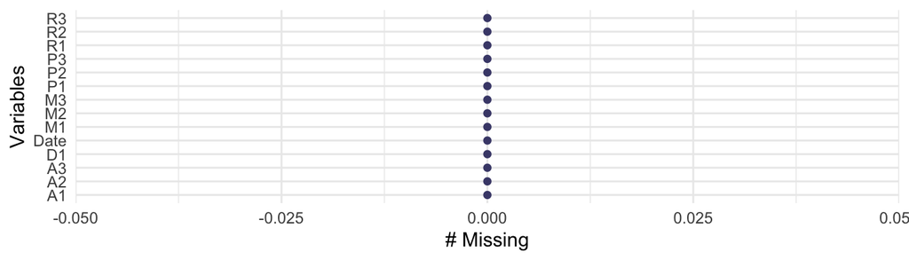

```r
gasoline %>%
  gg_miss_var()
```

```r
sum(duplicated(gasoline))
```

```
## [1] 0
```

There are no NA values and no duplicate values to worry about in my data.

## 3. Methodology

### 3.1 SARIMA (p, d, q) x (P, D, Q) model

For my gasoline data set, SARIMA was chosen because of the presence of a seasonal time series. SARIMA works well with the fact that the gasoline prices are dependent and related to the prices of the past, there is seasonality that SARIMA can detect such as, increase in prices in the summer due to vacationing, holiday travel patterns, and any maintenance cycles the gasoline must go through. SARIMA will track any trends the seasonality creates, whether the prices trend upward or downward over time, using recent prices to predict the next prices that may occur.

In this project, I have selected a SARIMA(1,1,1)(0,1,1)[52] model after numerous testing and comparison of different SARIMA models with different p, d, q and P, D, and Q. The SARIMA(1,1,1)(0,1,1)[52] proved to have the lowest AIC and was the simplest method that successfully applied to my data set.

I also specifically applied the Box-Jenkins methodology to compare and decide which SARIMA model to select which model was best, as it includes the steps to identify and test different models, different parameter, and necessitates thorough analysis of the resulting plots and tests to decide which model to use.

For the duration of the project, I specifically chose the variable A1 to focus on as it encompasses all grades and all formulation of gasoline, so for both my SARIMA modelling and GARCH modelling it is dealing with the data from the A1 variable.

### 3.2 GARCH(1,1)

I’ve also chosen to perform GARCH on my data set since GARCH is a method that often deals in prices. With my gasoline price data, it naturally fits with previous problems that have used GARCH in the past and similarly can be used to study volatility. GARCH stands for “Generalized Autoregressive Conditionally Heteroskedastic,” and is used to model variance that changes over time, able to capture how much the price is expected to fluctuate at a given point in time.

You will see further in this report that I have identified the presence of ARCH effects that allows me to conduct GARCH modeling on my data. The GARCH is applied to the residuals that I will have received from my SARIMA modeling that I will complete first. I will use GARCH(1,1), where there is 1 lagged square residual included and 1 lagged variance term included. This model assumes normal distribution, so I also further did GARCH models with student-t distribution and skewed student-t distribution to further account for the extreme values that occur in my data as a result of extreme economic events. The best performing model is decided with the lowest AIC and BIC, and the highest log-likelihood — the model with the lowest and highest of these three will indicate the best fit to the observed data.

## 4. Results

### 4.1 SARIMA Modeling and Results

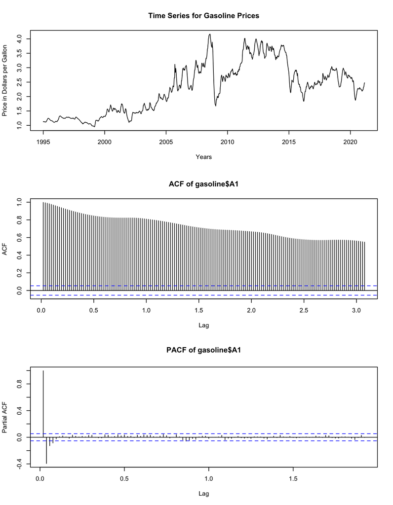

```r
# turning A1 gasoline into a time series object

gas_ts <- ts(gasoline$A1, frequency = 52, start = c(1995,1))
par(mfrow = c(3,1))
 plot(gas_ts, main = "Time Series for Gasoline Prices", xlab = "Years",
      ylab = "Price in Dollars per Gallon")
acf(gas_ts, main = "ACF of gasoline$A1", 160)
pacf(gas_ts, main = "PACF of gasoline$A1", 100)
```

The ACF of the time series of gasoline$A1 shows a slowly decaying trend with all spikes exceeding the confidence interval. This indicates high levels of trend dominating the plot. There is non-stationarity and high autocorrelation.

The PACF displays a significant spike at the beginning with the spikes significantly dropping off after it and remaining within the confidence interval for the most part. The ACF and PACF both indicate trend and non-stationarity which implies need for first differencing to remove the trend and make the series stationary.

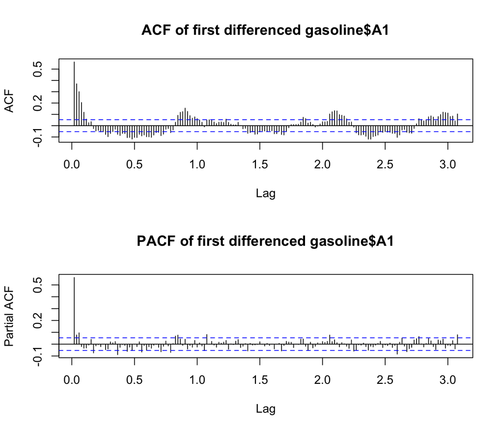

```r
# differencing the series to remove trend and non-stationarity
par(mfrow = c(2,1))
gas_diff <- diff(gas_ts)
acf(gas_diff, 160, main = "ACF of first differenced gasoline$A1")
pacf(gas_diff, 160, main = "PACF of first differenced gasoline$A1")
```

The ACF now properly displays a seasonality that mimics a yearly cycle, with 1.0 representing the 52nd week of a year. The spike clusters occur at roughly in periods around 1.0, 2.0, and 3.0, appearing like a seasonal pattern. I can assume this represents strong yearly seasonality.

The PACF again has a significant spike at the beginning and the remaining spikes appear mostly within the confidence interval in a random pattern and not reflecting seasonality at all. This more looks like white noise behavior and thus implies stationarity after differencing and a non-seasonal AR(1) component. (So far: p=1, d=1)

Now I must fit different SARIMA models to see which suits my series best. I have already determined p=1, d=1, and D=1. For a test, I’ll fit a SARIMA(1,1,1)(1,1,1)[52] model.

```
## <><><><><><><><><><><><><><>
##
## Coefficients:
##      Estimate     SE  t.value p.value
## ar1    0.6458 0.0420  15.3735  0.0000
## ma1   -0.1640 0.0558  -2.9392  0.0033
## sar1  -0.0069 0.0281  -0.2459  0.8058
## sma1  -0.9999 0.0388 -25.7672  0.0000
##
## sigma^2 estimated as 0.0015808 on 1304 degrees of freedom
##
## AIC = -3.473877  AICc = -3.473853  BIC = -3.45409
##
```

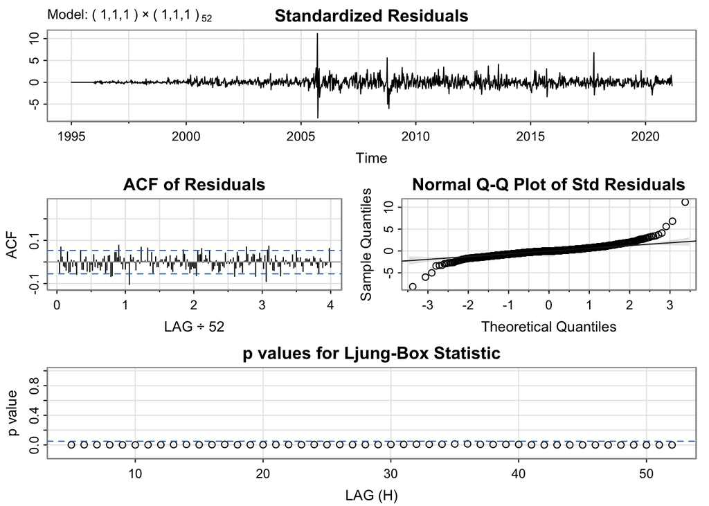

```r
model1 <- sarima(gas_ts, 1,1,1,1,1,1,52)
```

```r
model1
```

```
## $fit
##
## Call:
## arima(x = xdata, order = c(p, d, q), seasonal = list(order = c(P, D, Q), period = S),
##     include.mean = !no.constant, transform.pars = trans, fixed = fixed, optim.control = list(trace = trc,
##         REPORT = 1, reltol = tol))
##
## Coefficients:
##          ar1      ma1     sar1     sma1
##       0.6458  -0.1640  -0.0069  -0.9999
## s.e.  0.0420   0.0558   0.0281   0.0388
##
## sigma^2 estimated as 0.001581:  log likelihood = 2276.92,  aic = -4543.83
##
## $sigma2
## [1] 0.0015808
##
## $degrees_of_freedom
## [1] 1304
##
## $t.table
##      Estimate     SE  t.value p.value
## ar1    0.6458 0.0420  15.3735  0.0000
## ma1   -0.1640 0.0558  -2.9392  0.0033
## sar1  -0.0069 0.0281  -0.2459  0.8058
## sma1  -0.9999 0.0388 -25.7672  0.0000
##
## $ICs
##       AIC      AICc       BIC
## -3.473877 -3.473853 -3.454090
```

In the plot of standardized residuals, there is fluctuation around zero with no detectable trend or seasonality. It exhibits behavior similar to white noise with a few notable large spikes around 2005, 2008, and 2017. There is no structure as far as I can tell.

The normal QQ plot of standard residuals show the points following the line reasonably well aside from the tails.

The Ljung-Box statistic of the p-values tests the null hypothesis $H_0$: The residuals are white noise. Most residuals here appear below the dashed line and below 0.05

The AIC is -4543.83.

The ar1, ma1, and sma1 estimates and p-values show that those terms are either extremely useful or important for the model. The sar1 estimate and p-value on the other hand contradict the other three, with the p-value far surpassing a value of 0.05 and failing to reject $H_0$: the coefficient sar1 = 0. This indicates that our model might not exactly be SARIMA(1,1,1)(1,1,1)[52].

So instead of SARIMA(1,1,1)(1,1,1)[52], I can try SARIMA(1,1,1)(0,1,1)[52]

```
## <><><><><><><><><><><><><><>
##
## Coefficients:
##      Estimate     SE  t.value p.value
## ar1    0.6453 0.0420  15.3746  0.0000
## ma1   -0.1634 0.0557  -2.9327  0.0034
## sma1  -1.0000 0.0370 -27.0572  0.0000
##
## sigma^2 estimated as 0.001581586 on 1305 degrees of freedom
##
## AIC = -3.47536  AICc = -3.475346  BIC = -3.45953
##
```

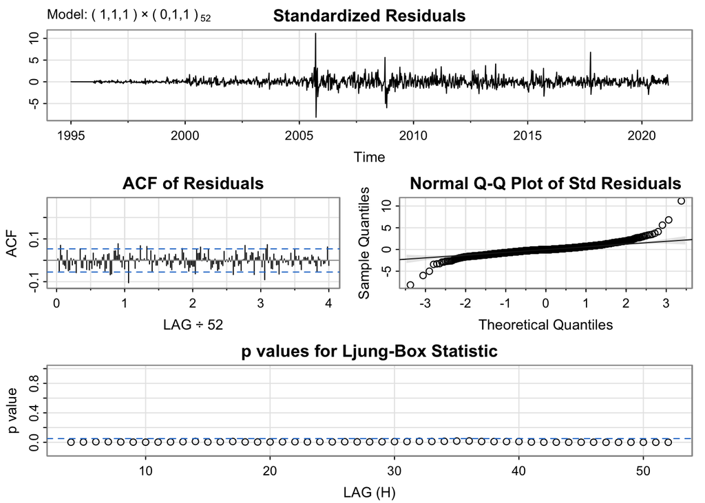

```r
model2 <- sarima(gas_ts, 1,1,1,0,1,1,52)
```

```r
model2
```

```
## $fit
##
## Call:
## arima(x = xdata, order = c(p, d, q), seasonal = list(order = c(P, D, Q), period = S),
##     include.mean = !no.constant, transform.pars = trans, fixed = fixed, optim.control = list(trace = trc,
##         REPORT = 1, reltol = tol))
##
## Coefficients:
##          ar1      ma1    sma1
##       0.6453  -0.1634  -1.000
## s.e.  0.0420   0.0557   0.037
##
## sigma^2 estimated as 0.001582:  log likelihood = 2276.89,  aic = -4545.77
##
## $sigma2
## [1] 0.001581586
##
## $degrees_of_freedom
## [1] 1305
##
## $t.table
##      Estimate     SE  t.value p.value
## ar1    0.6453 0.0420  15.3746  0.0000
## ma1   -0.1634 0.0557  -2.9327  0.0034
## sma1  -1.0000 0.0370 -27.0572  0.0000
##
## $ICs
##       AIC      AICc       BIC
## -3.475360 -3.475346 -3.459530
```

The report of the model displays an AIC of -4545.77, which is less than the AIC above, indicating that it is a better model.

The $t.table displays estimates and p-values that indicate the ar1, ma1, and sma1 terms are all significant and useful with their p-values being less than 0.05. The SARIMA(1,1,1)(0,1,1)[52] model is proving to be a better and simpler model than the SARIMA(1,1,1)(1,1,1)[52] model but I believe I should still compare more models to be sure that it is the best fit.

Next, I will try SARIMA(1,1,0)(0,1,1)[52].

```
## <><><><><><><><><><><><><><>
##
## Coefficients:
##      Estimate     SE  t.value p.value
## ar1    0.5297 0.0234  22.6171       0
## sma1  -1.0000 0.0337 -29.6324       0
##
## sigma^2 estimated as 0.001590933 on 1306 degrees of freedom
##
## AIC = -3.470967  AICc = -3.47096  BIC = -3.459095
##
```

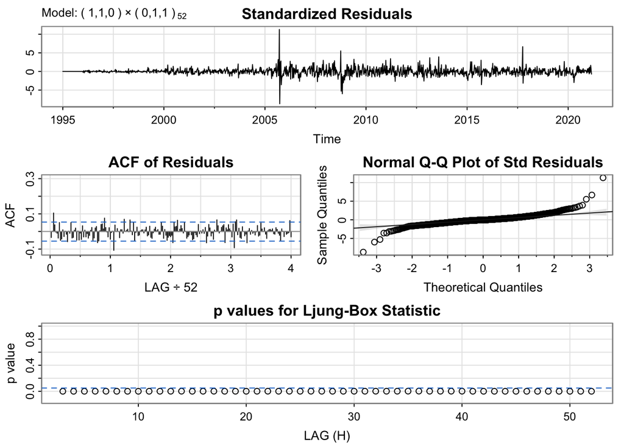

```r
model3 <- sarima(gas_ts, 1,1,0,0,1,1,52)
```

```r
model3
```

```
## $fit
##
## Call:
## arima(x = xdata, order = c(p, d, q), seasonal = list(order = c(P, D, Q), period = S),
##     include.mean = !no.constant, transform.pars = trans, fixed = fixed, optim.control = list(trace = trc,
##         REPORT = 1, reltol = tol))
##
## Coefficients:
##          ar1     sma1
##       0.5297  -1.0000
## s.e.  0.0234   0.0337
##
## sigma^2 estimated as 0.001591:  log likelihood = 2273.01,  aic = -4540.02
##
## $sigma2
## [1] 0.001590933
##
## $degrees_of_freedom
## [1] 1306
##
## $t.table
##      Estimate     SE  t.value p.value
## ar1    0.5297 0.0234  22.6171       0
## sma1  -1.0000 0.0337 -29.6324       0
##
## $ICs
##       AIC      AICc       BIC
## -3.470967 -3.470960 -3.459095
```

The AIC in the report is -4540.02, which is higher than both the SARIMA(1,1,1)(0,1,1)[52] and SARIMA(1,1,1)(1,1,1)[52] AICs of -4545.77 and -4543.83 respectively. Since the standard errors and coefficients also do not seem to be extremely large, I conclude that the SARIMA(1,1,0)(0,1,1)[52] model is not as good as the previous models and is not preferred, so I will move on to testing other models.

I will test a SARIMA(1,1,1)(0,1,0)[52] model.

```
## <><><><><><><><><><><><><><>
##
## Coefficients:
##     Estimate     SE t.value p.value
## ar1   0.6608 0.0384 17.1922   0e+00
## ma1  -0.1874 0.0504 -3.7182   2e-04
##
## sigma^2 estimated as 0.00325662 on 1306 degrees of freedom
##
## AIC = -2.884337  AICc = -2.88433  BIC = -2.872465
##
```

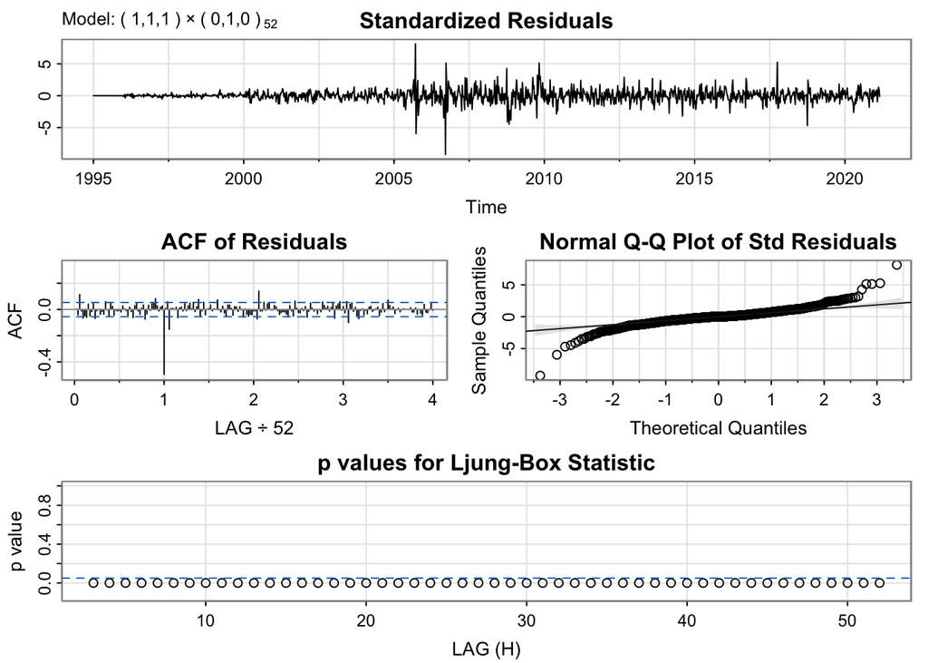

```r
model4 <- sarima(gas_ts, 1,1,1,0,1,0,52)
```

```r
model4
```

```
## $fit
##
## Call:
## arima(x = xdata, order = c(p, d, q), seasonal = list(order = c(P, D, Q), period = S),
##     include.mean = !no.constant, transform.pars = trans, fixed = fixed, optim.control = list(trace = trc,
##         REPORT = 1, reltol = tol))
##
## Coefficients:
##          ar1      ma1
##       0.6608  -0.1874
## s.e.  0.0384   0.0504
##
## sigma^2 estimated as 0.003257:  log likelihood = 1889.36,  aic = -3772.71
##
## $sigma2
## [1] 0.00325662
##
## $degrees_of_freedom
## [1] 1306
##
## $t.table
##     Estimate     SE t.value p.value
## ar1   0.6608 0.0384 17.1922   0e+00
## ma1  -0.1874 0.0504 -3.7182   2e-04
##
## $ICs
##       AIC      AICc       BIC
## -2.884337 -2.884330 -2.872465
```

The AIC of -3772.71 is much higher than all other AICs shown so far and shows that this is clearly not the best model by comparison.

```
## <><><><><><><><><><><><><><>
##
## Coefficients:
##      Estimate     SE  t.value p.value
## ma1    0.4471 0.0215  20.7837       0
## sma1  -1.0000 0.0289 -34.5483       0
##
## sigma^2 estimated as 0.001717728 on 1306 degrees of freedom
##
## AIC = -3.394365  AICc = -3.394358  BIC = -3.382493
##
```

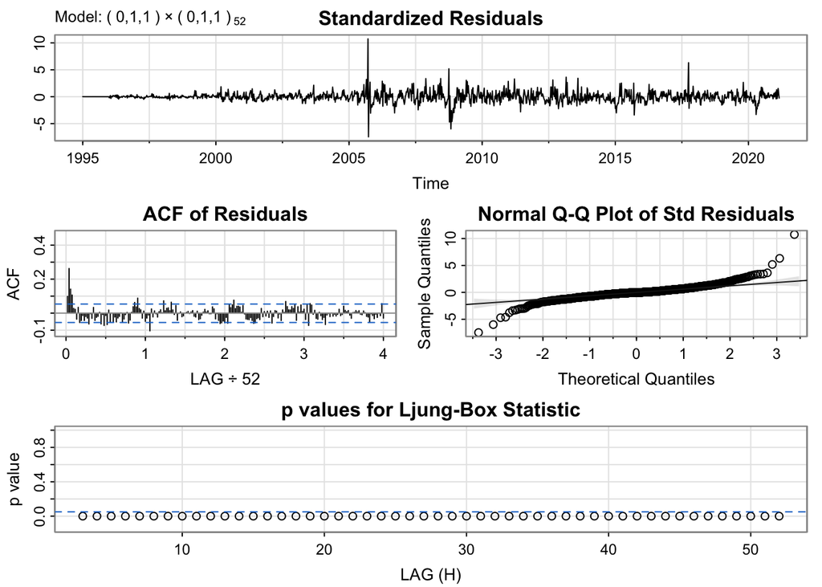

```r
model5 <- sarima(gas_ts, 0,1,1,0,1,1,52)
```

```r
model5
```

```
## $fit
##
## Call:
## arima(x = xdata, order = c(p, d, q), seasonal = list(order = c(P, D, Q), period = S),
##     include.mean = !no.constant, transform.pars = trans, fixed = fixed, optim.control = list(trace = trc,
##         REPORT = 1, reltol = tol))
##
## Coefficients:
##          ma1     sma1
##       0.4471  -1.0000
## s.e.  0.0215   0.0289
##
## sigma^2 estimated as 0.001718:  log likelihood = 2222.91,  aic = -4439.83
##
## $sigma2
## [1] 0.001717728
##
## $degrees_of_freedom
## [1] 1306
##
## $t.table
##      Estimate     SE  t.value p.value
## ma1    0.4471 0.0215  20.7837       0
## sma1  -1.0000 0.0289 -34.5483       0
##
## $ICs
##       AIC      AICc       BIC
## -3.394365 -3.394358 -3.382493
```

The AIC is -3.394, higher than model3 and therefore is higher than model1 and model2 and is very noticeable and makes this model not preferred in comparison to the SARIMA(1,1,1)(0,1,1)[52].

I conclude the SARIMA(1,1,1)(0,1,1)[52] model is the best and simplest model to use as I would like to forecast the next 12 data points of my data set.

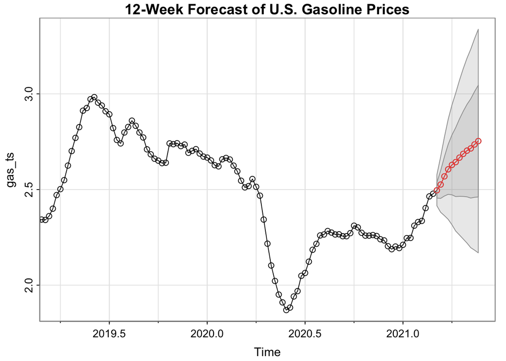

```r
gas_sarima <- sarima.for(gas_ts,
           n.ahead = 12,
           p = 1, d = 1, q = 1,
           P = 0, D = 1, Q = 1,
           S = 52)
title(
  main = "12-Week Forecast of U.S. Gasoline Prices",
)
```

```r
forecast_values <- data.frame(
  week = 1:12,
  predicted_price = gas_sarima$pred,
  lower = gas_sarima$pred - 1.96*gas_sarima$se,
  upper = gas_sarima$pred + 1.96*gas_sarima$se
)
round(forecast_values, 4)
```

| week | predicted_price | lower | upper |
| --- | --- | --- | --- |
| 1 | 2.4960 | 2.4166 | 2.5755 |
| 2 | 2.5260 | 2.3840 | 2.6680 |
| 3 | 2.5687 | 2.3676 | 2.7698 |
| 4 | 2.6055 | 2.3495 | 2.8614 |
| 5 | 2.6287 | 2.3221 | 2.9352 |
| 6 | 2.6434 | 2.2902 | 2.9965 |
| 7 | 2.6666 | 2.2705 | 3.0628 |
| 8 | 2.6864 | 2.2503 | 3.1225 |
| 9 | 2.7033 | 2.2299 | 3.1767 |
| 10 | 2.7147 | 2.2064 | 3.2231 |

[output cut: 2 more lines]

The next 12 data points are predicted to have an upward trend and increase in prices over the next 12 weeks. It appears that the prices will rise starting from a little below $2.50 and go up to around $2.75 per gallon. The prediction intervals, the gray areas also known and as the range of the lower and upper column, increase as time goes on, indicating that the predictions will become more unreliable as we create longer term predictions.

### 4.2 GARCH Modeling and Results

I’ve chosen to perform GARCH on my data since it is a series that deals in prices. As I attempt to predict future prices, it is similar to previous problems where they’ve sparked interest on studying volatility or variability of the time series. GARCH stands for “Generalized Autoregressive Conditionally Heteroskedastic,” so before I can use GARCH on my data set, I want to check if heteroskedasticity even exists.

```r
returns <- diff(log(gas_ts))
FinTS::ArchTest(returns)
```

```
##
##  ARCH LM-test; Null hypothesis: no ARCH effects
##
## data:  returns
## Chi-squared = 221.02, df = 12, p-value < 2.2e-16
```

As the p-values is less than 0.05 and therefore statistically significant, we are able to reject the null hypothesis that there are no ARCH effects and accept that ARCH effect do exist and volatility is present in my data set. By applying a GARCH model to my data, I will be able to capture the changing variance of my data over time and will show me if I can expect my predictions to fluctuate.

```r
gas_residuals <- model2$fit$residuals
# garch(gas_residuals, c(1,1))

# Normal predictions
gas_garch <- garchFit(
  ~ garch(1,1),
  data = gas_residuals
)
```

[output not shown]

[output cut: 33 more lines]

[output not shown]

```r
start_date <- as.Date("1995-02-01")
dates <- seq(start_date, by = "week", length.out = length(gas_residuals))
```

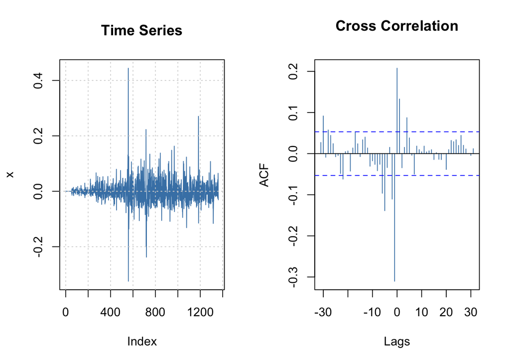

```r
par(mfrow = c(1,2))
plot(gas_garch, which = 1)
plot(gas_garch, which = 12)
```

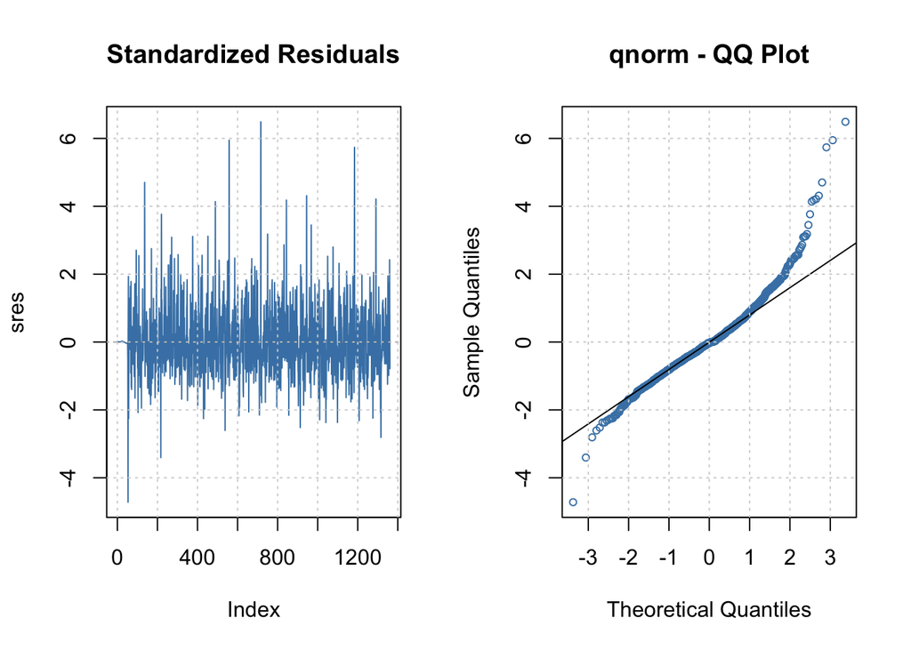

```r
par(mfrow = c(1,2))

plot(gas_garch, which = 9)
plot(gas_garch, which = 13)
```

The QQ plot has a heavy tail at the right of it and raises above it. The left tail falls a little below the normal reference line but it is not as heavy as the right tail. This s-curve indicates a heavy tailed distribution. These indicates the gas prices to experience extreme price events, which is not common for normal distributions.

In order to address the irregularities of the plots that are not consistent with normal distributions, I will be fitting a student-t distribution and skewed student-t distribution in addition to it.

```r
# student-t
gas_garch_t <- garchFit(~ garch(1,1), data = gas_residuals,
                          cond.dist = "std")
```

[output not shown]

[output cut: 41 more lines]

[output not shown]

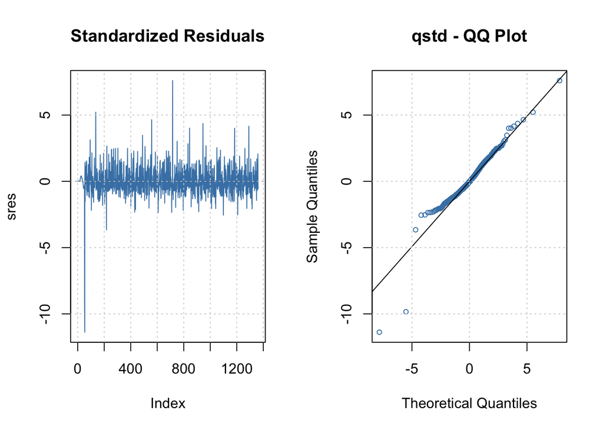

```r
par(mfrow = c(1,2))
plot(gas_garch_t, which = 9)
plot(gas_garch_t, which = 13)
```

The heavy spike past -10 is a far increase than the spike in the beginning of the normal distribution standardized residual plot. This increase however is typical when switching to a heavier tailed distribution from the normal distribution. This indicates to me that the model is now being more reflective of how truly extreme that early outlier truly was relative to the rest of the series, The bulk of the residuals appear more contained and consistent in comparison to the normal distribution version.

The points in the QQ plot follow the reference line more closely than the previous QQ plot did. The tails still show some deviation, the tail on the left falling below the reference line and a couple points around -10. This suggests the student-t distribution handles the right tail well but the left tail still remains heavy. The tail deviation suggests the presence of sharp downward price crashes.

Because the left tail are slightly more extreme, I also will try a skewed student-t distribution prediction.

```r
# skewed student-t
gas_garch_sst <- garchFit(~ garch(1,1), data = gas_residuals,
                          cond.dist = "sstd")
```

[output not shown]

[output cut: 44 more lines]

[output not shown]

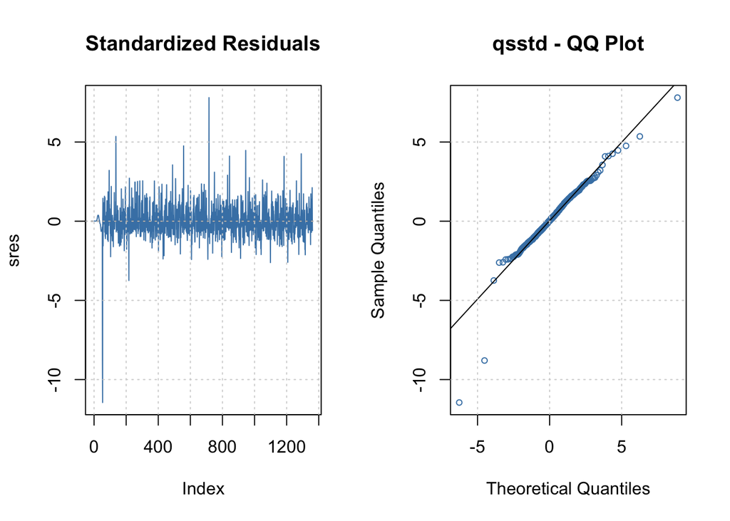

```r
par(mfrow = c(1,2))
plot(gas_garch_sst, which = 9)
plot(gas_garch_sst, which = 13)
```

The residuals past the 200 index appear consistent and symmetrical more than the normal and student-t distribution versions. The model no longers needs to accommodate asymmetric shocks and the plot looks more balanced.

The QQ plot is the most balanced between the normal distribution and student-t distribution with the tight adherence to the reference line. The right tail shows some points drifting but not to any severe point. On the left tail, there are still a couple points around -10 but they are less severe than the student-t distribution. The skewness of the skewed student-t distribution is absorbing some of the asymmetry between the price shocks.

```r
summary(gas_garch)
```

```
##
## Title:
##  GARCH Modelling
##
## Call:
##  garchFit(formula = ~garch(1, 1), data = gas_residuals)
##
## Mean and Variance Equation:
##  data ~ garch(1, 1)
## <environment: 0xa9145b850>
##  [data = gas_residuals]
##
## Conditional Distribution:
##  norm
##
## Coefficient(s):
##         mu       omega      alpha1       beta1
## 2.2756e-05  6.2425e-07  3.0119e-01  7.8382e-01
##
## Std. Errors:
##  based on Hessian
##
## Error Analysis:
##         Estimate  Std. Error  t value Pr(>|t|)
## mu     2.276e-05   2.642e-04    0.086    0.931
## omega  6.243e-07   4.009e-07    1.557    0.119
## alpha1 3.012e-01   3.150e-02    9.560   <2e-16 ***
## beta1  7.838e-01   1.691e-02   46.357   <2e-16 ***
## ---
## Signif. codes:  0 '***' 0.001 '**' 0.01 '*' 0.05 '.' 0.1 ' ' 1
##
## Log Likelihood:
##  2933.345    normalized:  2.155287
##
## Description:
##  Thu Sep 10 16:46:05 2026 by user:
##
##
##
## Standardised Residuals Tests:
##                                    Statistic    p-Value
##  Jarque-Bera Test   R    Chi^2  1305.6081620 0.00000000
##  Shapiro-Wilk Test  R    W         0.9476263 0.00000000
##  Ljung-Box Test     R    Q(10)    17.7163540 0.05994104
##  Ljung-Box Test     R    Q(15)    24.2537129 0.06090836
##  Ljung-Box Test     R    Q(20)    27.4094893 0.12413141
##  Ljung-Box Test     R^2  Q(10)     7.5136311 0.67622662
##  Ljung-Box Test     R^2  Q(15)    10.9250744 0.75788741
##  Ljung-Box Test     R^2  Q(20)    11.1603716 0.94195706
##  LM Arch Test       R    TR^2      9.3306916 0.67445549
##
## Information Criterion Statistics:
##       AIC       BIC       SIC      HQIC
## -4.304695 -4.289365 -4.304712 -4.298957
```

Looking at the AIC, BIC, and log-likelihood is how I will determine which of the different distributions of the model performed the best.

The GARCH(1,1) model with normal distribution had a Log Likelihood of 2933.345 and a normalized 2.155287. It also had an AIC of -4.304695, and a BIC of -4.289365.

```r
summary(gas_garch_t)
```

```
##
## Title:
##  GARCH Modelling
##
## Call:
##  garchFit(formula = ~garch(1, 1), data = gas_residuals, cond.dist = "std")
##
## Mean and Variance Equation:
##  data ~ garch(1, 1)
## <environment: 0xa942153b8>
##  [data = gas_residuals]
##
## Conditional Distribution:
##  std
##
## Coefficient(s):
##         mu       omega      alpha1       beta1       shape
## 3.5111e-07  1.5211e-09  8.1179e-01  6.2386e-01  3.2128e+00
##
## Std. Errors:
##  based on Hessian
##
## Error Analysis:
##         Estimate  Std. Error  t value Pr(>|t|)
## mu     3.511e-07   1.412e-05    0.025    0.980
## omega  1.521e-09   2.247e-07    0.007    0.995
## alpha1 8.118e-01   1.356e-01    5.987 2.13e-09 ***
## beta1  6.239e-01   2.260e-02   27.599  < 2e-16 ***
## shape  3.213e+00   3.576e-01    8.984  < 2e-16 ***
## ---
## Signif. codes:  0 '***' 0.001 '**' 0.01 '*' 0.05 '.' 0.1 ' ' 1
##
## Log Likelihood:
##  3084.214    normalized:  2.266138
##
## Description:
##  Thu Sep 10 16:46:05 2026 by user:
##
##
##
## Standardised Residuals Tests:
##                                    Statistic      p-Value
##  Jarque-Bera Test   R    Chi^2  3.574918e+04 0.0000000000
##  Shapiro-Wilk Test  R    W      8.522859e-01 0.0000000000
##  Ljung-Box Test     R    Q(10)  3.543383e+01 0.0001052675
##  Ljung-Box Test     R    Q(15)  4.194139e+01 0.0002294673
##  Ljung-Box Test     R    Q(20)  4.473447e+01 0.0011986875
##  Ljung-Box Test     R^2  Q(10)  1.778304e+02 0.0000000000
##  Ljung-Box Test     R^2  Q(15)  1.783719e+02 0.0000000000
##  Ljung-Box Test     R^2  Q(20)  1.790146e+02 0.0000000000
##  LM Arch Test       R    TR^2   2.143537e+02 0.0000000000
##
## Information Criterion Statistics:
##       AIC       BIC       SIC      HQIC
## -4.524928 -4.505766 -4.524955 -4.517755
```

The student-t distribution resulted in a Log Likelihood of 3084.214 and a normalized 2.266138. It had an AIC of -4.524928 and a BIC of -4.505766.

```r
summary(gas_garch_sst)
```

```
##
## Title:
##  GARCH Modelling
##
## Call:
##  garchFit(formula = ~garch(1, 1), data = gas_residuals, cond.dist = "sstd")
##
## Mean and Variance Equation:
##  data ~ garch(1, 1)
## <environment: 0xa8e7252a0>
##  [data = gas_residuals]
##
## Conditional Distribution:
##  sstd
##
## Coefficient(s):
##         mu       omega      alpha1       beta1        skew       shape
## 1.2963e-05  1.5211e-09  7.7842e-01  6.2246e-01  1.1663e+00  3.3136e+00
##
## Std. Errors:
##  based on Hessian
##
## Error Analysis:
##         Estimate  Std. Error  t value Pr(>|t|)
## mu     1.296e-05   1.470e-05    0.882    0.378
## omega  1.521e-09   2.240e-07    0.007    0.995
## alpha1 7.784e-01   1.202e-01    6.474 9.54e-11 ***
## beta1  6.225e-01   2.197e-02   28.337  < 2e-16 ***
## skew   1.166e+00   3.873e-02   30.116  < 2e-16 ***
## shape  3.314e+00   3.626e-01    9.138  < 2e-16 ***
## ---
## Signif. codes:  0 '***' 0.001 '**' 0.01 '*' 0.05 '.' 0.1 ' ' 1
##
## Log Likelihood:
##  3095.765    normalized:  2.274626
##
## Description:
##  Thu Sep 10 16:46:05 2026 by user:
##
##
##
## Standardised Residuals Tests:
##                                    Statistic      p-Value
##  Jarque-Bera Test   R    Chi^2  2.728852e+04 0.0000000000
##  Shapiro-Wilk Test  R    W      8.642076e-01 0.0000000000
##  Ljung-Box Test     R    Q(10)  3.219933e+01 0.0003709284
##  Ljung-Box Test     R    Q(15)  3.831054e+01 0.0008116709
##  Ljung-Box Test     R    Q(20)  4.128923e+01 0.0034192681
##  Ljung-Box Test     R^2  Q(10)  1.304745e+02 0.0000000000
##  Ljung-Box Test     R^2  Q(15)  1.310546e+02 0.0000000000
##  Ljung-Box Test     R^2  Q(20)  1.317878e+02 0.0000000000
##  LM Arch Test       R    TR^2   1.483635e+02 0.0000000000
##
## Information Criterion Statistics:
##       AIC       BIC       SIC      HQIC
## -4.540434 -4.517439 -4.540473 -4.531826
```

The skewed student-t distribution resulted in a Log Likelihood of 3095.765 and a normalized 2.274626. It had an AIC of -4.540434 and a BIC of -4.517439.

Not only did the skewed student-t distribution result in the highest log likelihood, meaning the model did the best to fit the observed data, it also had the lowest AIC and BIC to further indicate its better fit.

Seeing as the GARCH(1,1) model with a skewed student-t distribution performed the best, I will use it to predict the volatility of at least the next 12 data points, the next 12 weeks, like I did with the SARIMA model.

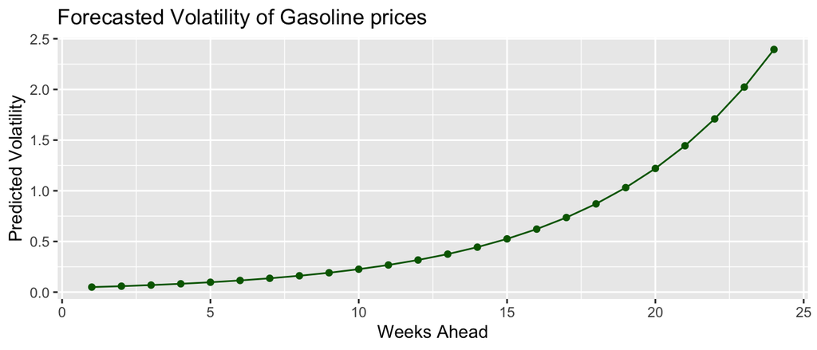

```r
# using garch to predict the volatility of the next 12 weeks

garch_prediction <- predict(gas_garch_sst, n.ahead = 24)
garch_df <- as.data.frame(garch_prediction)
garch_df$week <- 1:24

# plot
ggplot(garch_df, aes(x = week, y = standardDeviation)) +
  geom_line(color = "darkgreen") +
  geom_point(color = "darkgreen") +
  labs(
    title = "Forecasted Volatility of Gasoline prices",
    x = "Weeks Ahead",
    y = "Predicted Volatility"
  )
```

```r
garch_df %>%
  select(week, meanForecast, meanError, standardDeviation) %>%
  round(4)
```

| week | meanForecast | meanError | standardDeviation |
| --- | --- | --- | --- |
| 1 | 0 | 0.0496 | 0.0496 |
| 2 | 0 | 0.0587 | 0.0587 |
| 3 | 0 | 0.0695 | 0.0695 |
| 4 | 0 | 0.0823 | 0.0823 |
| 5 | 0 | 0.0974 | 0.0974 |
| 6 | 0 | 0.1152 | 0.1152 |
| 7 | 0 | 0.1364 | 0.1364 |
| 8 | 0 | 0.1614 | 0.1614 |
| 9 | 0 | 0.1911 | 0.1911 |
| 10 | 0 | 0.2262 | 0.2262 |

[output cut: 14 more lines]

In the short term, the volatility of gasoline prices are relatively stable and reliable, but as time extends into long term, the more volatile and unpredictable prices are.

## Conclusion and Future Study

This project intended to model and forecast weekly U.S. retail gasoline prices from January 1995 to January 2021. I wanted to observe how gasoline prices shifted over time and their relation to patterns and seasonality, and whether I could attribute any world events to explain the observed data. To do so, I chose two complementary time series methods of modelling: SARIMA and GARCH. The SARIMA exploration determined that the best model to use via AIC comparison was SARIMA(1,1,1)(0,1,1)[52]. This 12 week forecast projected a moderate upward trend in gasoline prices, rising from approximately $2.50 to $2.75 per gallon. As time progressed in the forecast, the prediction intervals also widened to match the expectation that prediction becomes less reliable the further into the future that you want to predict.

The GARCH(1,1) model was applied to the SARIMA residuals to address the volatility that the gasoline prices experienced over the period of 1995 to 2021. The presence of ARCH effects were confirmed first in order to apply GARCH and I then compared the different plots and summary results of the GARCH(1,1) model with different distributions. The comparison with different distributions was necessary as the results with just the assumption of a normal distribution displayed QQ plots with heavy tails and outliers that concerned me. I decided to compare the normal distribution results with the results from a student-t distribution and skewed student-t distribution. These distributions were selected for their generalizing qualities and ability to expect larger unexpected values that are consistent with large political and economic events in history that may have influenced gasoline prices. After comparing the log-likelihood, AIC, and BIC, the skewed student-t distribution of the GARCH(1,1) model performed the best at showing a clear and accurate representation of the data, so I used it to predict at least the next 12 weeks. I actually modeled a forecast of 24 weeks just to see how much the volatility could vary over time. It showed low predicted volatility in the short term, about first 5 weeks, and then increased exponentially as the forecast extended further than 5 weeks. This is consistent with the SARIMA model that showed a prediction interval that increased as time progressed, where predictions become less reliable the further in the future you predict.

For future study, there is a lot that can be improved on and added to this study. More models and different models would increase how interpretable the data and forecast are. In addition, my GARCH(1,1) model is symmetric, and an asymmetric model may be beneficial to capture the structure of the model where there are unseen effects of the past volatility on future volatility that I was not able to identify in the symmetric model. I cannot predict what sort of political or world changing events may occur, but the prediction analysis that I am attempting can help people understand what will happen to gasoline prices when they do occur. The time series plot reflected spikes in prices that followed global events, and hopefully further study will be able to accurately estimate the future gasoline prices that follow events like those.

## References

Mau Rua. “U.S. Gasoline and Diesel Retail Prices 1995–2021.” Kaggle, 2021. https://www.kaggle.com/datasets/mruanova/us-gasoline-and-diesel-retail-prices-19952021.

U.S. Energy Information Administration. “Weekly Retail Gasoline and Diesel Prices.” Washington D.C., 2021. https://www.eia.gov/dnav/pet/pet_pri_gnd_dcus_nus_w.htm.